# Praktikum 6 Anreg

# Library

```r
library(readxl) # untuk membaca data
library(GGally) # untuk menghasilkan matriks hubungan antarpeubah
library(corrplot) # untuk menghasilkan matriks korelasi
library(dplyr) # untuk manipulasi data
library(car) # untuk memeriksa multikolinearitas
library(stargazer) # untuk menampilkan hasil perbandingan regresi
library(lmtest) # untuk uji kehomogenan ragam sisaan dan saling bebas
library(olsrr) # untuk pemeriksaan amatan tidak biasa
```

Data

```r
data <- read_excel("C:/Users/ATIKAH MAULINA/OneDrive/Documents/STK 4/ANREG/Anreg_UAS/ANREG DATA CO2.xlsx")

data # menampilkan data
```

```
## # A tibble: 30 × 7
##    Negara                Y     X1    X2    X3     X4    X5
##    <chr>             <dbl>  <dbl> <dbl> <dbl>  <dbl> <dbl>
##  1 Argentina             3  8536. 1624. 0.919  16.5  0.098
##  2 Australia            15 51983. 5159. 0.873   3.33 0.112
##  3 Austria               7 48716. 3546. 0.685 108.   0.358
##  4 Brazil                2  7074. 1379. 0.869  25.0  0.5
##  5 Brunei Darussalam    21 26834. 9176. 0.748  84.9  0
##  6 Bulgaria              5 10760. 2665. 0.733  60.3  0.211
##  7 Canada               14 43538. 7495. 0.820   4.24 0.239
##  8 China                 8 10627. 2466. 0.635 150.   0.149
##  9 Colombia              2  5340.  814. 0.776  45.6  0.32
## 10 Denmark               5 60985. 2637. 0.882 146.   0.395
## # ℹ 20 more rows
```

```r
str(data) # menampilkan tipe data setiap peubah
```

```
## tibble [30 × 7] (S3: tbl_df/tbl/data.frame)
##  $ Negara: chr [1:30] "Argentina" "Australia" "Austria" "Brazil" ...
##  $ Y     : num [1:30] 3 15 7 2 21 5 14 8 2 5 ...
##  $ X1    : num [1:30] 8536 51983 48716 7074 26834 ...
##  $ X2    : num [1:30] 1624 5159 3546 1379 9176 ...
##  $ X3    : num [1:30] 0.919 0.873 0.685 0.869 0.748 ...
##  $ X4    : num [1:30] 16.51 3.33 108.06 24.96 84.9 ...
##  $ X5    : num [1:30] 0.098 0.112 0.358 0.5 0 0.211 0.239 0.149 0.32 0.395 ...
```

```r
summary(data) # menampilkan ringkasan data
```

```
##     Negara                Y                X1                X2
##  Length:30          Min.   : 0.150   Min.   :  829.8   Min.   : 379.6
##  Class :character   1st Qu.: 2.000   1st Qu.: 5309.2   1st Qu.: 824.5
##  Mode  :character   Median : 4.500   Median : 8811.4   Median :2098.7
##                     Mean   : 5.644   Mean   :18720.3   Mean   :2538.1
##                     3rd Qu.: 7.000   3rd Qu.:33257.2   3rd Qu.:3273.6
##                     Max.   :21.000   Max.   :60985.5   Max.   :9175.9
##        X3               X4               X5
##  Min.   :0.2163   Min.   :  3.33   Min.   :0.00000
##  1st Qu.:0.5793   1st Qu.: 49.31   1st Qu.:0.08825
##  Median :0.7168   Median :104.26   Median :0.18600
##  Mean   :0.6780   Mean   :144.72   Mean   :0.24320
##  3rd Qu.:0.8140   3rd Qu.:149.32   3rd Qu.:0.34850
##  Max.   :0.9194   Max.   :557.42   Max.   :0.90700
```

```r
dt <- select(data, -Negara)
```

# Eksplorasi Data

## Peubah Respon

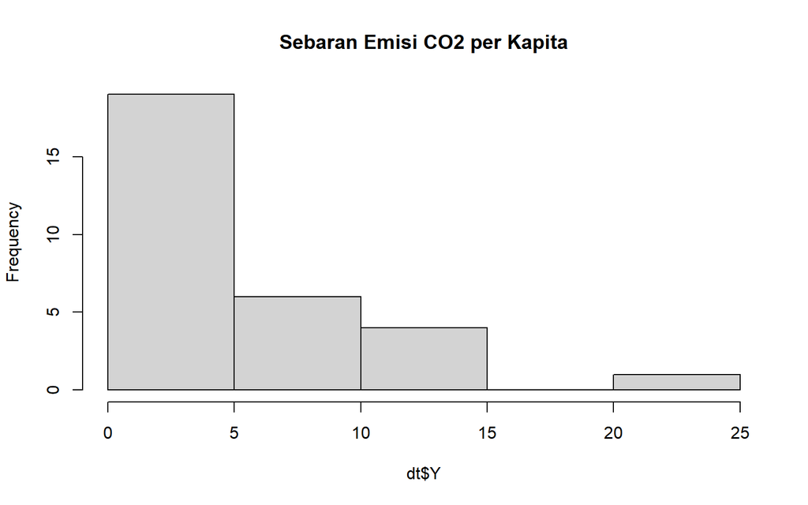

```r
hist(dt$Y, main = "Sebaran Emisi CO2 per Kapita")
```

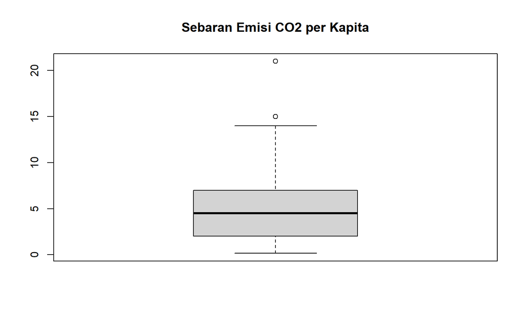

```r
boxplot(dt$Y, main = "Sebaran Emisi CO2 per Kapita")
```

## Peubah Pennjelas vs Peubah Respon

### GDP per Kapita

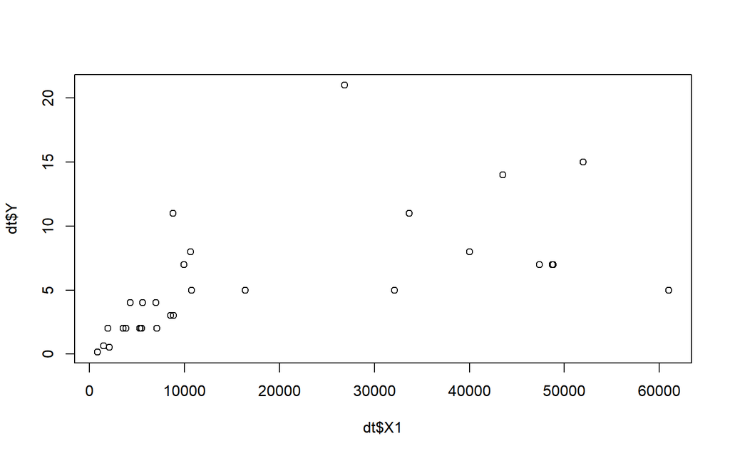

```r
plot(dt$X1, dt$Y)
```

Hubungan antara peubah $Y$ dan $X1$ cenderung tidak linear, ada beberapa amatan dengan nilai $X$ jauh dari amatan lainnya.

### Rata-Rata Konsumsi Jumlah Energi per Kapita

[figure not shown]

```r
plot(dt$X2, dt$PPM)
```

### Jumlah Penduduk Daerah Perkotaan

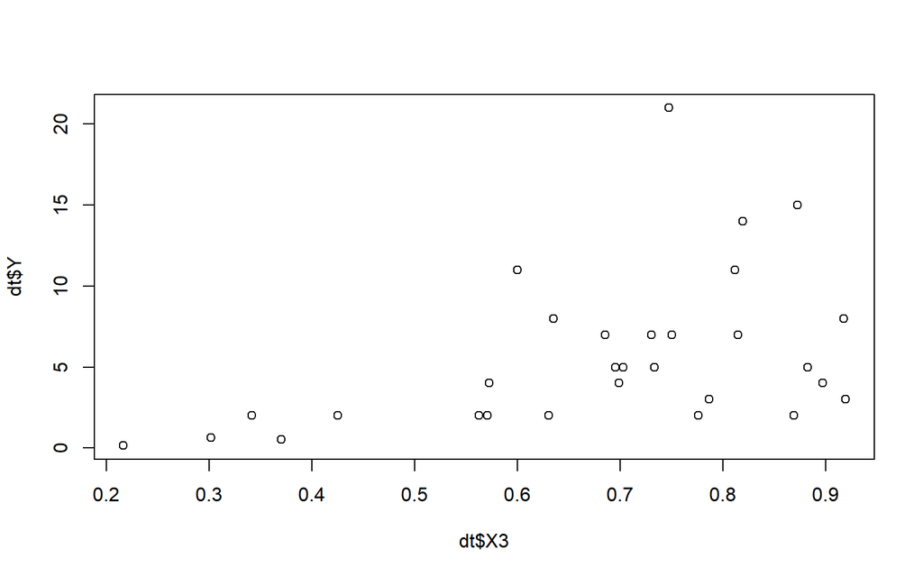

```r
plot(dt$X3, dt$Y)
```

Hubungan antara peubah $Y$ dan $X3$ cenderung tidak linear, ada banyak amatan dengan nilai $X$ jauh dari amatan lainnya.

### Kepadatan Penduduk

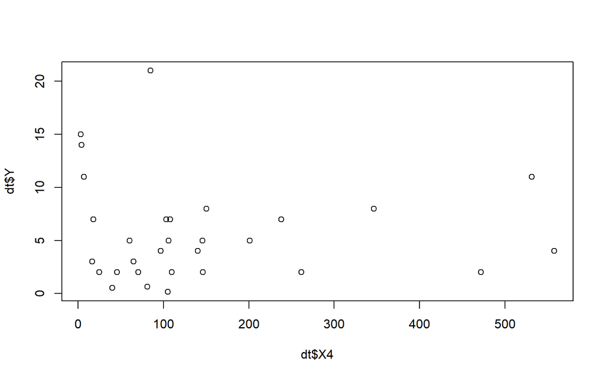

```r
plot(dt$X4, dt$Y)
```

Hubungan antara peubah $Y$ dan $X4$ tidak linear, ada banyak amatan dengan nilai $X$ jauh dari amatan lainnya.

### Penggunaan Energi Alternatif

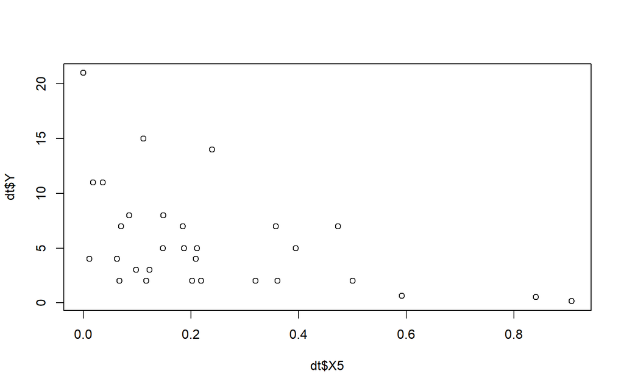

```r
plot(dt$X5, dt$Y)
```

Hubungan antara peubah $Y$ dan $X5$ cenderung tidak linear, ada beberapa amatan dengan nilai X jauh dari amatan lainnya.

## Korelasi

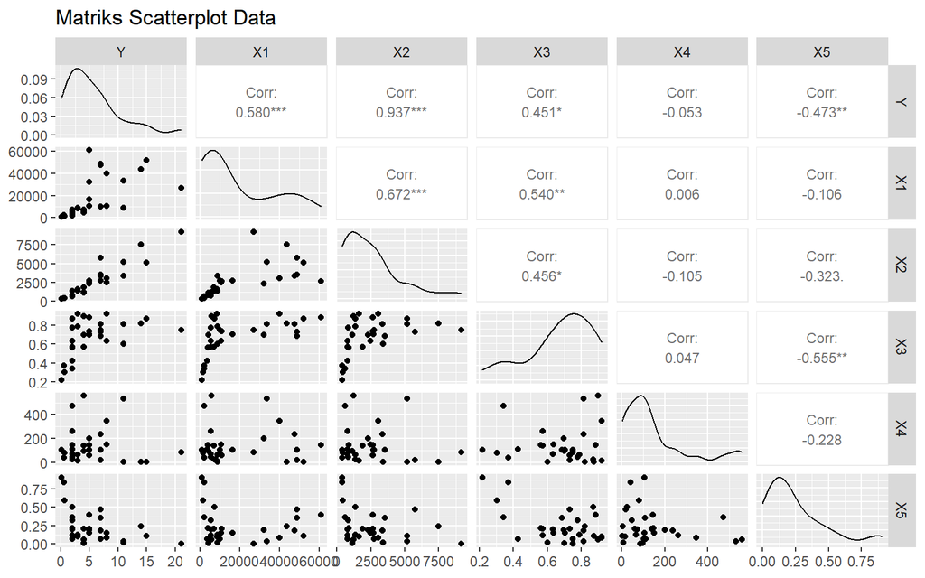

```r
ggpairs(dt,
        upper = list(continuous = wrap('cor', size = 3)),
        title = "Matriks Scatterplot Data")
```

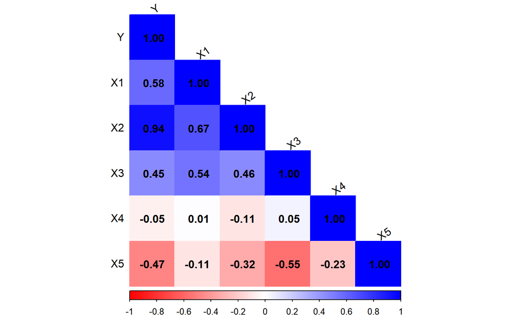

```r
cor_matrix <- cor(dt, use = "complete.obs")

corrplot(cor_matrix, method = "color", type = "lower",
         col = colorRampPalette(c("red", "white", "blue"))(200),
         addCoef.col = "black", tl.col = "black", tl.srt = 35)
```

Hasil matriks scatter plot dan korelasi menunjukkan bahwa peubah respon Emisi $CO_2$ per kapita ($Y$) memiliki hubungan positif dengan GDP per Kapita ($X1$), Rata-Rata Konsumsi Jumlah Energi per Kapita ($X2$), dan Jumlah Penduduk Daerah Perkotaan ($X3$). Sementara itu, peubah respon ($Y$) memiliki hubungan negatif dengan Kepadatan Penduduk ($X4$) dan Penggunaan Energi Alternatif ($X5$).

Selain itu, terdapat banyak korelasi tinggi antar peubah penjelas, baik lebih dari 0.5 maupun kurang dari -0.5. Beberapa di antaranya adalah: 1. GDP per Kapita ($X1$) dan Rata-Rata Konsumsi Jumlah Energi per Kapita ($X2$) memiliki korelasi positif sebesar 0.67. 2. GDP per Kapita ($X1$) dan Jumlah Penduduk Daerah Perkotaan ($X3$) memiliki korelasi positif sebesar 0.54. 3. Jumlah Penduduk Daerah Perkotaan ($X_3$) dan Penggunaan Energi Alternatif ($X_5$) menunjukkan korelasi negatif yang cukup kuat, yaitu sebesar -0.55.

Korelasi yang tinggi ini mengindikasikan adanya potensi multikolinearitas, yang dapat mempengaruhi keakuratan model yang akan dibentuk.

# Pemodelan

```r
model1 = lm(formula = Y ~ ., data = dt)
summary(model1)
```

```
##
## Call:
## lm(formula = Y ~ ., data = dt)
##
## Residuals:
##     Min      1Q  Median      3Q     Max
## -3.8255 -0.7250  0.0006  0.5456  3.9120
##
## Coefficients:
##               Estimate Std. Error t value Pr(>|t|)
## (Intercept)  3.218e+00  1.798e+00   1.790   0.0860 .
## X1          -2.028e-06  2.430e-05  -0.083   0.9342
## X2           2.011e-03  1.969e-04  10.214 3.25e-10 ***
## X3          -2.131e+00  2.242e+00  -0.951   0.3513
## X4          -1.785e-04  2.029e-03  -0.088   0.9306
## X5          -4.807e+00  1.735e+00  -2.771   0.0106 *
## ---
## Signif. codes:  0 '***' 0.001 '**' 0.01 '*' 0.05 '.' 0.1 ' ' 1
##
## Residual standard error: 1.536 on 24 degrees of freedom
## Multiple R-squared:  0.9151, Adjusted R-squared:  0.8974
## F-statistic: 51.72 on 5 and 24 DF,  p-value: 4.513e-12
```

Persamaan yang terbentuk adalah
$$\hat{Y}=
3.218 −0.000002028 X1 + 0.002011 X2 -2.131 X3 −0.0001785 X4 −4.8067
X5$$

Pada ringkasan model ini dapat dilihat bahwa secara simultan minimal ada satu peubah penjelas yang berpengaruh signifikan terhadap Emisi $CO_2$.Hal tersebut ditunjukkan oleh nilai uji F yang signifikan p-value < 0,05, sehingga model secara keseluruhan signifikan.Secara parsial, terdapat dua peubah yang signifikan pada taraf nyata 5%, yaitu $X2$ dan $X5$. Sementara itu $X1$, $X3$, dan $X4$ tidak signifikan.

# Pemeriksaan Multikolinearitas

## Perubahan Peubah

```r
mod1 <- lm(Y ~ ., dt[1:2])
mod2 <- lm(Y ~ ., dt[1:3])
mod3 <- lm(Y ~ ., dt[1:4])
mod4 <- lm(Y ~ ., dt[1:5])
mod5 <- lm(Y ~ ., dt)

stargazer(mod1, mod2, mod3, mod4, mod5,
          type = "text", single.row = TRUE)
```

```
##
## =======================================================================================================================================
##                                                                     Dependent variable:
##                     -------------------------------------------------------------------------------------------------------------------
##                                                                              Y
##                              (1)                     (2)                    (3)                    (4)                    (5)
## ---------------------------------------------------------------------------------------------------------------------------------------
## X1                   0.0001*** (0.00004)     -0.00002 (0.00002)      -0.00003 (0.00002)     -0.00003 (0.00002)     -0.00000 (0.00002)
## X2                                            0.002*** (0.0002)      0.002*** (0.0002)      0.002*** (0.0002)      0.002*** (0.0002)
## X3                                                                     1.655 (2.011)          1.541 (2.035)          -2.131 (2.242)
## X4                                                                                            0.002 (0.002)         -0.0002 (0.002)
## X5                                                                                                                  -4.807** (1.735)
## Constant               2.893*** (1.030)         0.455 (0.492)          -0.472 (1.230)         -0.663 (1.268)         3.218* (1.798)
## ---------------------------------------------------------------------------------------------------------------------------------------
## Observations                  30                     30                      30                     30                     30
## R2                          0.336                   0.882                  0.885                  0.888                  0.915
## Adjusted R2                 0.313                   0.874                  0.872                  0.870                  0.897
## Residual Std. Error    3.976 (df = 28)         1.704 (df = 27)        1.714 (df = 26)        1.729 (df = 25)        1.536 (df = 24)
## F Statistic         14.197*** (df = 1; 28) 101.382*** (df = 2; 27) 67.005*** (df = 3; 26) 49.513*** (df = 4; 25) 51.724*** (df = 5; 24)
## =======================================================================================================================================
## Note:                                                                                                       *p<0.1; **p<0.05; ***p<0.01
```

Terdapat perubahan tanda arah korelasi pada peubah $X1$ dan $X3$, perubahan dugaan parameter juga cukup besar ketika ditambahkan peubah lainnya. Hasil ini mengindikasikan adanya permasalahan dalam model.

## Perubahan Banyak Data

```r
mod5_1 <- lm(Y ~ ., dt[1:15,])
stargazer(summary(mod5)$coefficients, summary(mod5_1)$coefficients,
          type = "text",
          font.size = "small")
```

```
##
## ===================================================
##             Estimate Std. Error t value Pr(> | t| )
## ---------------------------------------------------
## (Intercept)  3.218     1.798     1.790     0.086
## X1          -0.00000  0.00002   -0.083     0.934
## X2           0.002     0.0002   10.214       0
## X3           -2.131    2.242    -0.951     0.351
## X4          -0.0002    0.002    -0.088     0.931
## X5           -4.807    1.735    -2.771     0.011
## ---------------------------------------------------
##
## ===================================================
##             Estimate Std. Error t value Pr(> | t| )
## ---------------------------------------------------
## (Intercept)  2.565     4.154     0.618     0.552
## X1          -0.00001  0.00004   -0.116     0.910
## X2           0.002     0.0003    6.102    0.0002
## X3           -1.445    4.504    -0.321     0.756
## X4           0.004     0.011     0.363     0.725
## X5           -5.226    3.320    -1.574     0.150
## ---------------------------------------------------
```

Terdapat dugaan parameter yang mengalami perubahan besar ketika jumlah amatan berbeda, mengindikasikan model bermasalah dan tidak stabil.

## Akar Ciri

```r
x <- dt[-1]
r <- cor(x)
(ev <- eigen(r)$values)
```

```
## [1] 2.3548906 1.2101427 0.7895648 0.4619713 0.1834306
```

```r
# Simultan
if ((max(ev) / min(ev)) <= 100) {
  cat("Tidak ada multikolinearitas\n")
} else if ((max(ev) / min(ev)) > 100 & (max(ev) / min(ev)) <= 1000) {
  cat("Ada multikolinearitas yang lemah\n")
} else {
  cat("Ada multikolinearitas yang kuat\n")
}
```

```
## Tidak ada multikolinearitas
```

```r
# Parsial
if (all((max(ev) / ev) <= 1000)) {
  cat("Tidak ada multikolinearitas\n")
} else {
  cat("Ada multikolinearitas pada peubah penjelas ke:", which((max(ev) / ev) > 1000), "\n")
}
```

```
## Tidak ada multikolinearitas
```

## Nilai VIF

```r
vif(model1)
```

```
##       X1       X2       X3       X4       X5
## 2.598424 2.224830 2.232688 1.142739 1.935126
```

Hasil pemeriksaan dengan akar ciri menyatakan tidak ada multikolinearitas pada model karena tidak ada nilai $k>100$ secara simultan. Nilai VIF juga menunjukkan tidak ada peubah yang VIF nya lebih dari 10. Namun masih ada peubah yang mengalami perubahan tanda arah korelasi. Artinya ada permasalahan lain yang mungkin belum tertangani, perlu dilakuan uji asumsi dan pemeriksaan pencilan, leverage, dan amatan berpengaruh.

# Pengujian Asumsi

## Eksplorasi Grafik

### Plot Sisaan vs Y duga

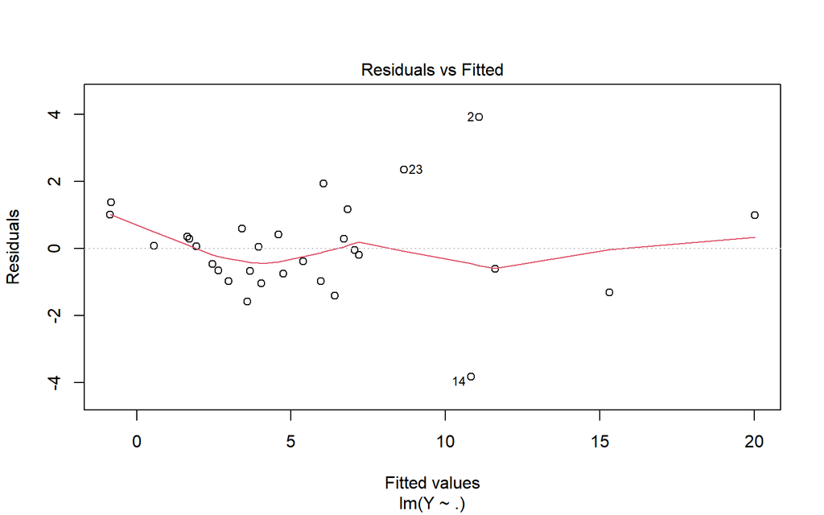

```r
plot(model1,1)
```

### Plot Sisaan vs Urutan

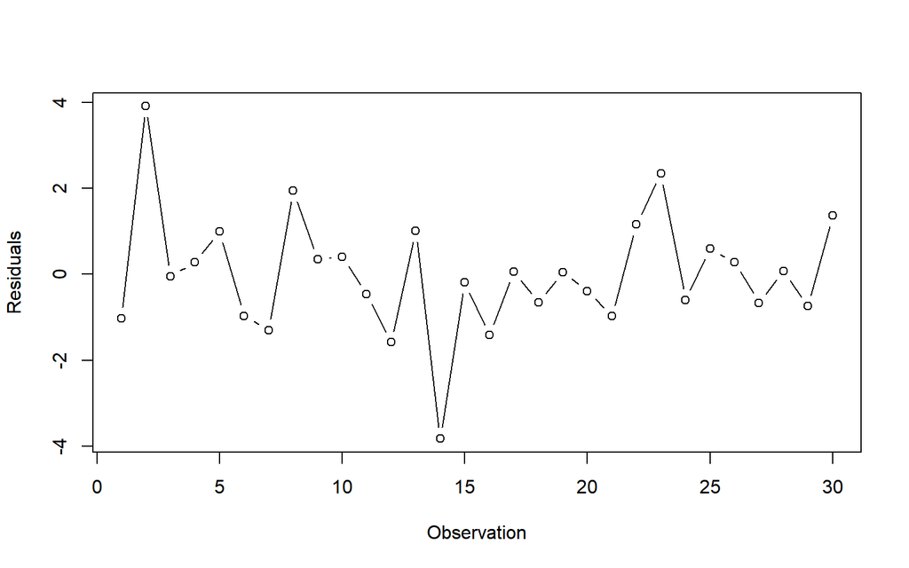

```r
plot(x = 1:dim(dt)[1],
     y = model1$residuals,
     type = 'b',
     ylab = "Residuals",
     xlab = "Observation")
```

Tebaran titik-titik sisaan menyebar secara acak dan tidak membentuk pola geometris tertentu → sisaan saling bebas. Namun, fluktuasi yang cukup tajam dan bolak-balik antara nilai positif dan negatif yang ekstrem pada beberapa amatan awal (seperti amatan 2 dan 14) secara visual memberikan sedikit indikasi adanya autokorelasi negatif, meskipun secara umum sebagian besar sisaan lainnya bergerak acak di sekitar sumbu nol.

### QQ plot

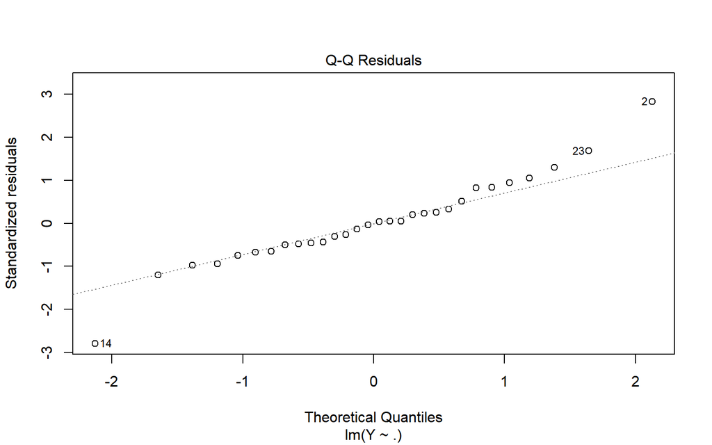

```r
plot(model1,2)
```

sebagian besar amatan berada sangat dekat dan mengikuti garis diagonal referensi. Namun, pada kedua ujung grafik, terdapat amatan yang cenderung menjauh dan tidak mengikuti garis pola, khususnya amatan nomor 14 di ujung kiri bawah serta amatan nomor 2 dan 23 di ujung kanan atas. Hal ini mengindikasikan adanya pencilan (outliers) yang berpotensi menyebabkan sisaan tidak menyebar normal sepenuhnya.

## Uji Formal

### Nilai harapan sisaan sama dengan nol

```r
t.test(model1$residuals,mu = 0,conf.level = 0.95)
```

```
##
##  One Sample t-test
##
## data:  model1$residuals
## t = -2.3919e-16, df = 29, p-value = 1
## alternative hypothesis: true mean is not equal to 0
## 95 percent confidence interval:
##  -0.5218428  0.5218428
## sample estimates:
##     mean of x
## -6.102974e-17
```

Nilai p pada uji t sama dengan 1 yang lebih besar dari alpha 5%, sehingga dinyatakan asumsi nilai harapan sisaan sama dengan nol terpenuhi.

### Ragam sisaan homogen

```r
bptest(model1)
```

```
##
##  studentized Breusch-Pagan test
##
## data:  model1
## BP = 8.4897, df = 5, p-value = 0.1312
```

### Sisaan saling bebas

```r
dwtest(model1)
```

```
##
##  Durbin-Watson test
##
## data:  model1
## DW = 2.3156, p-value = 0.7728
## alternative hypothesis: true autocorrelation is greater than 0
```

Nilai p pada uji durbin watson sama dengan 0.7728 yang lebih besar dari alpha 5%, sehingga dinyatakan asumsi sisaan saling bebas terpenuhi.

### Normalitas Sisaan

```r
shapiro.test(model1$residuals)
```

```
##
##  Shapiro-Wilk normality test
##
## data:  model1$residuals
## W = 0.95049, p-value = 0.1743
```

Nilai p pada uji shapiro wilk sama dengan 0.1743 yang lebih besar dari alpha 5%, sehingga dinyatakan asumsi normalitas sisaan terpenuhi.

Semua asumsi sisaan terpenuhi, tetapi model masih buruk, kemungkinan karena keberadaan amatan yang tidak biasa seperti pencilan, leverage, atau amatan berpengaruh.

# Pemeriksaan Amatan Tidak Biasa

```r
#fungsi
ri_stud <- rstudent(model1)
ri_stan <- rstandard(model1)
hii_fungsi <- hatvalues(model1)

#manual
X <- model.matrix(model1)
X_inv_xt <- X %*% solve(t(X) %*% X) %*% t(X)
hii_manual <- diag(X_inv_xt)
anova_model <- anova(model1)
s <- sqrt(anova_model["Residuals", "Mean Sq"])
ei <- model1$residuals
ri_manual <- ei/(s*sqrt(1-hii_manual))

nilai <- data.frame(ri_stud, ri_stan, ri_manual, hii_fungsi, hii_manual)
nilai
```

```
##        ri_stud     ri_stan   ri_manual hii_fungsi hii_manual
## 1  -0.74609955 -0.75308761 -0.75308761 0.20238585 0.20238585
## 2   3.40267295  2.83481514  2.83481514 0.19303638 0.19303638
## 3  -0.03511174 -0.03586595 -0.03586595 0.17295954 0.17295954
## 4   0.22440635  0.22898231  0.22898231 0.35545095 0.35545095
## 5   0.94618936  0.94826052  0.94826052 0.53441990 0.53441990
## 6  -0.64424965 -0.65224716 -0.65224716 0.06873454 0.06873454
## 7  -0.98022701 -0.98102759 -0.98102759 0.25012721 0.25012721
## 8   1.31756175  1.29781305  1.29781305 0.05187971 0.05187971
## 9   0.24593907  0.25089899  0.25089899 0.14511376 0.14511376
## 10  0.32216223  0.32835123  0.32835123 0.34628757 0.34628757
## 11 -0.30606818 -0.31201628 -0.31201628 0.08308827 0.08308827
## 12 -1.21340163 -1.20163458 -1.20163458 0.26491461 0.26491461
## 13  0.82321526  0.82879940  0.82879940 0.37127843 0.37127843
## 14 -3.34029903 -2.79993087 -2.79993087 0.20899255 0.20899255
```

[output cut: 16 more lines]

## Pencilan

```r
for (i in 1:dim(nilai)[1]){
  absri <- abs(nilai[,2])
  pencilan <- which(absri > 2)
}
pencilan
```

```
## [1]  2 14
```

Amatan ke-2 dan ke-14 terdeteksi sebagai pencilan.

## Leverage

```r
n <- dim(dt)[1]
p <- length(model1$coefficients)

for (i in 1:dim(nilai)[1]){
  cutoff <- 2*p/n
  titik_leverage <- which(hii_fungsi > cutoff)
}
titik_leverage
```

```
##  5 25
##  5 25
```

Amatan ke-5 dan ke-25 terdeteksi sebagai titik leverage.

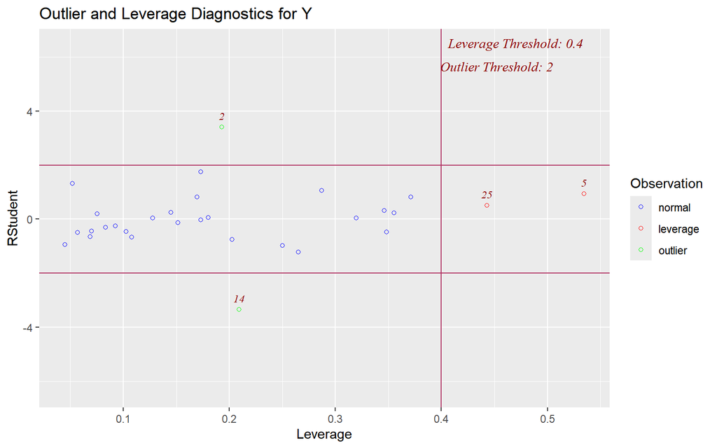

```r
ols_plot_resid_lev(model1)
```

Plot yang terbentuk dari fungsi `ols_plot_resid_lev()` menyatakan bahwa amatan ke-2 dan ke-14 teridentifikasi secara jelas sebagai pencilan (outlier) karena nilai studentized residual (RStudent) keduanya berada di luar batas ambang batas $\pm 2$. Sementara itu, amatan ke-5 dan ke-25 teridentifikasi memiliki titik ungkit (leverage) yang tinggi karena nilai leverage-nya melebihi batas ambang batas 0.4.

## Amatan Berpengaruh

### Jarak Cook

```r
di <- cooks.distance(model1)
f <- qf(0.05,p,n-p, lower.tail = F)
data.frame(di, di>f)
```

```
##              di di...f
## 1  2.398430e-02  FALSE
## 2  3.203933e-01  FALSE
## 3  4.483646e-05  FALSE
## 4  4.819215e-03  FALSE
## 5  1.720253e-01  FALSE
## 6  5.233288e-03  FALSE
## 7  5.350379e-02  FALSE
## 8  1.536056e-02  FALSE
## 9  1.780930e-03  FALSE
## 10 9.518669e-03  FALSE
## 11 1.470332e-03  FALSE
## 12 8.672847e-02  FALSE
## 13 6.760658e-02  FALSE
## 14 3.452181e-01  FALSE
```

[output cut: 16 more lines]

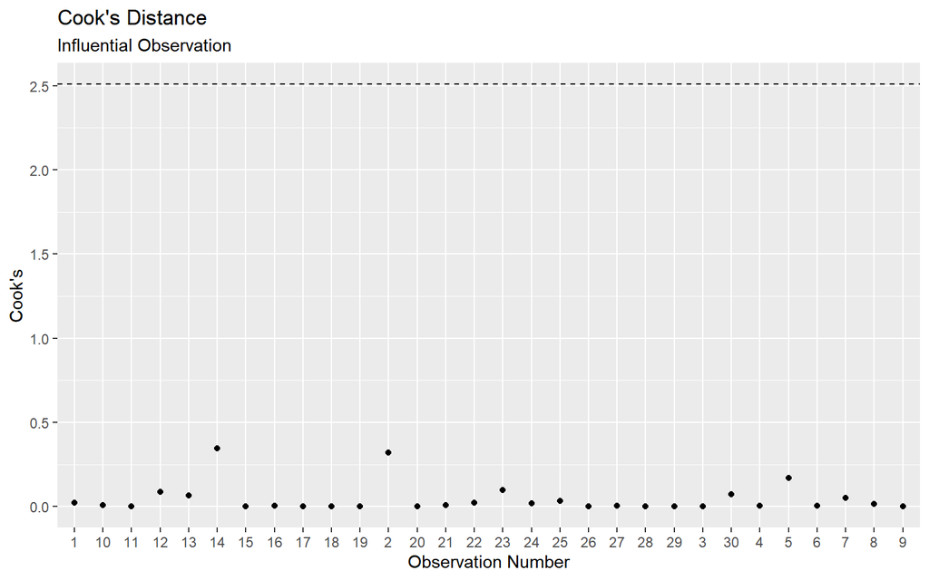

```r
cooks_crit = f
model_cooks <- cooks.distance(model1)
df <- data.frame(obs = names(model_cooks),
                 cooks = model_cooks)
ggplot(df, aes(y = cooks, x = obs)) +
  geom_point() +
  geom_hline(yintercept = cooks_crit, linetype="dashed") +
  labs(title = "Cook's Distance",
       subtitle = "Influential Observation ",
       x = "Observation Number",
       y = "Cook's")
```

Pemeriksaan amatan berpengaruh dengan jarak cook tidak dihasilkan nilai yang melebihi ambang batas.

### DFBETAS

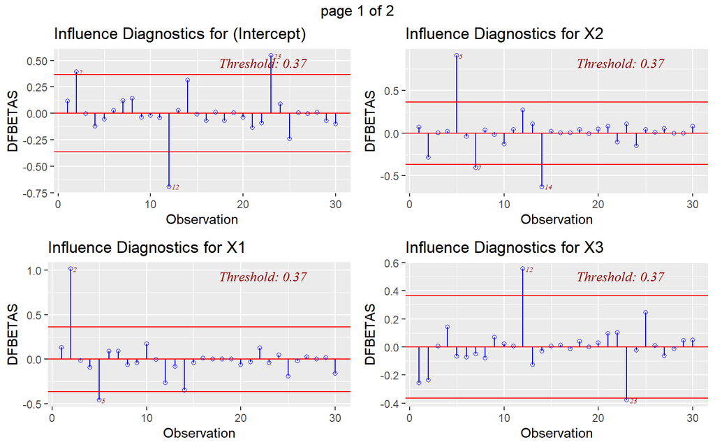

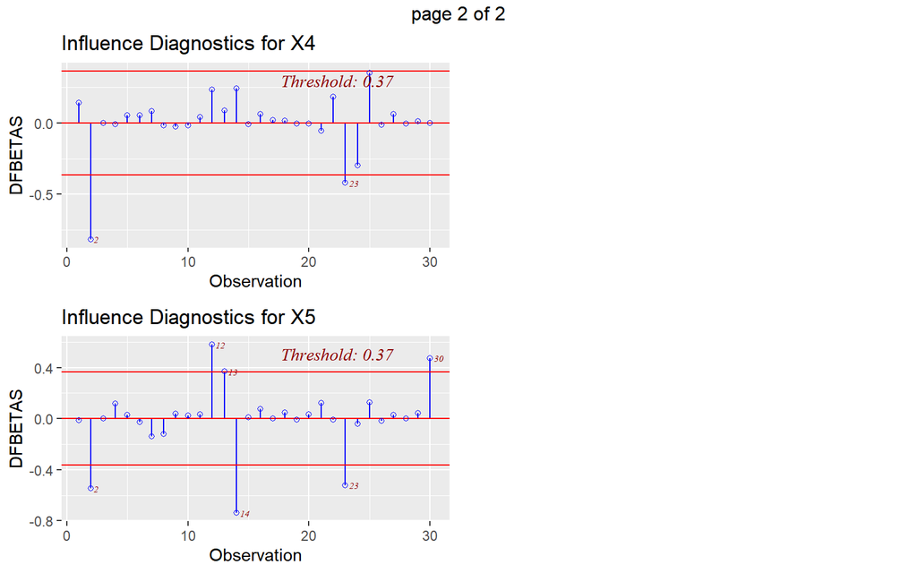

```r
ols_plot_dfbetas(model1)
```

Hasil DFBETAS akan menunjukkan pengaruh observasi terhadap setiap koefisien regresi, sehingga ada output untuk setiap parameter regresi. DFBETAS mengukur seberapa besar koefisien regresi berubah jika suatu observasi dihapus dari model.

### DFFITS

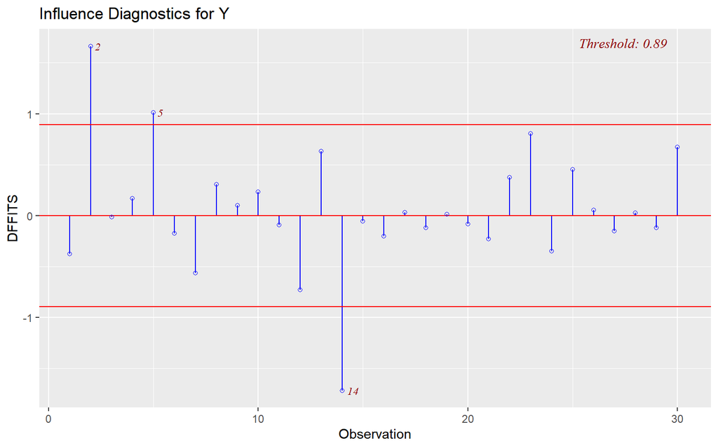

```r
ols_plot_dffits(model1)
```

Hasil DFFITS menunjukkan pengaruh observasi terhadap nilai prediksi $Y$, sehingga hanya menghasilkan satu output. DFFITS mengukur seberapa besar nilai prediksi $\hat{Y}_i$ berubah jika suatu observasi dihapus dari model, sehingga lebih tepat digunakan jika ingin melihat pengaruh observasi terhadap hasil model secara keseluruhan.

```r
DFFITSi <- dffits(model1)

amatan_berpengaruh <- vector("list", dim(nilai)[1])
for (i in 1:dim(nilai)[1]) {
  cutoff <- 2 * sqrt((p / n))
  amatan_berpengaruh[[i]] <- which(abs(DFFITSi) > cutoff)
}
berpengaruh <- unlist(amatan_berpengaruh)
amatan_berpengaruh <- sort(unique(berpengaruh))
amatan_berpengaruh
```

```
## [1]  2  5 14
```

Amatan ke-2, ke-5 dan ke-14 termasuk amatan berpengaruh sehingga sangat riskan jika disisihkan. Perlu ditelusuri lebih lanjut

# Pemodelan Penyisihan Amatan

```r
# gunakan peubah penjelas yang sudah diseleksi

dt1 <- dt %>% slice(-2)
model2 <- lm(Y ~ X1 + X2 + X3 + X4 + X5, dt1)

dt2 <- dt %>% slice(-5)
model3 <- lm(Y ~ X1 + X2 + X3 + X4 + X5, dt2)

dt3 <- dt %>% slice(-14)
model4 <- lm(Y ~ X1 + X2 + X3 + X4 + X5, dt3)

dt4 <- dt %>% slice(-c(2, 5))
model5 <- lm(Y ~ X1 + X2 + X3 + X4 + X5, dt4)

dt5 <- dt %>% slice(-c(2, 14))
model6 <- lm(Y ~ X1 + X2 + X3 + X4 + X5, dt5)

dt6 <- dt %>% slice(-c(5, 14))
model7 <- lm(Y ~ X1 + X2 + X3 + X4 + X5, dt6)

dt7 <- dt %>% slice(-c(2, 5, 14))
model8 <- lm(Y ~ X1 + X2 + X3 + X4 + X5, dt7)
```

```r
get_metrics <- function(model) {
  adj_r2 <- summary(model)$adj.r.squared
  sse <- sum(model$residuals^2)
  return(c(adj_r2, sse))
}

model_metrics <- data.frame(
  Model = c("Model 1", "Model 2", "Model 3", "Model 4", "Model 5",
            "Model 6", "Model 7", "Model 8" ),
  Adjusted_R2 = sapply(list(model1, model2, model3, model4,
                            model5, model6, model7, model8),
                       function(m) get_metrics(m)[1]),
  SSE = sapply(list(model1, model2, model3, model4,
                    model5, model6, model7, model8),
               function(m) get_metrics(m)[2])
)

print(model_metrics)
```

```
##     Model Adjusted_R2      SSE
## 1 Model 1   0.8973885 56.63887
## 2 Model 2   0.9204336 37.67387
## 3 Model 3   0.8431163 54.51680
## 4 Model 4   0.9301897 38.13775
## 5 Model 5   0.8693642 34.25737
## 6 Model 6   0.9482118 24.20062
## 7 Model 7   0.8890663 37.90618
## 8 Model 8   0.9090549 23.25898
```

```r
stargazer(model1, model3, model8, type = "text", font.size = "small", report = "vc*p")
```

```
##
## ========================================================================================
##                                             Dependent variable:
##                     --------------------------------------------------------------------
##                                                      Y
##                              (1)                    (2)                    (3)
## ----------------------------------------------------------------------------------------
## X1                         -0.00000               0.00001                -0.00001
##                           p = 0.935              p = 0.738              p = 0.719
##
## X2                         0.002***               0.002***               0.002***
##                           p = 0.000             p = 0.00000             p = 0.000
##
## X3                          -2.131                 -1.978                 -1.589
##                           p = 0.352              p = 0.389              p = 0.316
##
## X4                         -0.0002                -0.0003                 0.001
##                           p = 0.931              p = 0.888              p = 0.657
##
## X5                         -4.807**               -4.860**               -3.269**
##                           p = 0.011              p = 0.011              p = 0.015
##
## Constant                    3.218*                 3.319*                 2.381*
##                           p = 0.087              p = 0.079              p = 0.070
##
## ----------------------------------------------------------------------------------------
## Observations                  30                     29                     27
## R2                          0.915                  0.871                  0.927
## Adjusted R2                 0.897                  0.843                  0.909
## Residual Std. Error    1.536 (df = 24)        1.540 (df = 23)        1.052 (df = 21)
## F Statistic         51.724*** (df = 5; 24) 31.095*** (df = 5; 23) 52.977*** (df = 5; 21)
## ========================================================================================
## Note:                                                        *p<0.1; **p<0.05; ***p<0.01
```